# script_DGE_python_Chapter10(13May20219 (1)

## Chapter 10.1: Overlapping Generations Models with Idiosyncratic Income Uncertainty --- Python Code

[figure not shown]

#### By BURKHARD HEER and ALFRED MAUSSNER, University of Augsburg

In the following, we study the computation of the steady state of the 70-Period OLG model described in Section 10.1 of our book on 'Dynamic General Equilibrium Modeling: Computational Methods and Applications' (3rd edition, in progress). We consider a medium-scale overlapping generations model where workers are subject to idiosyncratic productivity shocks so that income is stochastic at the individual level (but not at the aggregate level).

In the following, we present a detailed discussion of the PYTHON program that computes the stationary solution to this heterogeneous-agent economy. We apply value function iteration to solve for the individual policy functions. In order to maximize the right-hand side of the Bellman equation, we use Golden Section Search as described in Section 11.6.1 of our book. In order to interpolate between grid points of the value function, we use linear or cubic interpolation as described in Section 11.2.3 of our book. In addition, we propose an algorithm for the computation of the stationary distribution.

The PYTHON program 'AK70_stochastic_income.py' can be downloaded from our web page

https://www.uni-augsburg.de/de/fakultaet/wiwi/prof/vwl/maussner/dgebook/

If you have any questions, suggestions or comments, please send an email to: Burkhard.Heer@wiwi.uni-augsburg.de

#### Description of the model

We study a medium-sized OLG model with respect to its ability to model inequality. It is characterized by the following features:

1. life-cycle savings,
2. uncertain lifetime,
3. uncertain earnings,
4. pay-as-you-go pensions.

Huggett (1996) analyses this kind of model with respect to the income and wealth distribution; in particular, he wonders if the OLG model is able to explain the fact that the (endogenous) wealth inequality is larger than the earnings and income inequality. We modify his model slightly.

### Demographics

A period, $t$, corresponds to one year. At each period $t$, a new generation of households is born. Newborns have a real-life age of 21 denoted by $s=1$. All generations retire at the end of age $s=T^W=45$ (corresponding to a real-life age of 65) and live up to a maximum age of $s=T=70$ (real-life age 90). The number of periods during retirement is equal to $T^R=T-T^W=25$.

Let $N_t(s)$ denote the number of agents of age $s$ at $t$. We denote the total population at $t$ by $N_t$. At $t$, all agents of age $s$ survive until age $s+1$ with probability $\phi_{t}^s$, where $\phi_{t}^0=1$ and $\phi_{t}^T=0$. In period $t$, the newborn cohort grows at rate $n_t$: \begin{equation} N_{t}(1) = (1+n_t) N_{t-1}(1).\end{equation} We consider the steady state where the survival probabilities and the population growth rate are constant, $\phi^s_t=\phi^s$ and $n_t=n$.

#### Households

Each household comprises one (possibly retired) worker. Households maximize expected intertemporal utility at the beginning of age 1 in period $t$ \begin{equation} \label{Ch93lifeutil2} \max \sum_{s=1}^J \beta^{s-1} \left(\Pi_{j=1}^s \phi_{t+j-1}^{j-1}\right)\; \mathbb{E}_t \; \left[ u(c_{t+s-1}^{s}, l_{t+s-1}^{s} ) + v(g_{t+s-1})\right],\end{equation} where $ \beta>0$ denotes the discount factor. Instantaneous utility $u(c,1-l)$ is specified as a function of consumption $c$ and and leisure $1-l$: \begin{equation} \label{util_instantaneous} u(c,1-l)= \frac{\left(c^\gamma (1-l)^{1-\gamma} \right)^{1-\eta}}{1-\eta} \end{equation} where $1/\eta$ denotes the intertemporal elasticity of substitution (IES) and $\gamma$ is the share of consumption in utility.

During working life, the labor supply of the $s$-year-old household amounts to $0 \le l^s\le l^{max}$, $s=1,\ldots,T^W$, where we impose a constraint on the maximum working hours $l^{max}$. During retirement, $l^s_t\equiv 0$ for $s=T^W+1,\ldots,T$.

Utility from government consumption, $v(g_t)$, is additive, so government consumption per capita, $g_t$, does not have any direct effect on household behavior (only indirectly through its effects on transfers and taxes).

Total gross labor income of the $s$-year-old worker in period $t$, $\epsilon(s,\theta,e) A_t w_t l^s_t$, consists of the product of his idiosyncratic productivity $\epsilon(s,\theta,e)$, aggregate productivity $A_t$, the wage per efficiency unit $w_t$ and his working time $l^s_t$. Aggregate productivity $A_t$ grows at the exogenous rate $g_A$, which is also equal to the economic growth rate of per capita income in steady state. The household's idiosyncratic labor productivity $\epsilon(s,\theta,e)$ is stochastic and also depends on his age $s$ according to $\epsilon(s,\theta,e)=\theta e \bar y^s$. The stochastic component $\theta$ follows a Markov process and takes only a finite number $n_\theta$ of possible values in the set $\Theta=\{\theta_1=\underline{\theta},\ldots,\theta_{n_\theta}=\overline{\theta}\}$ with $\theta_i<\theta_{i+1}$ for $i=1,\ldots,n_\theta-1$. Let $prob(\theta'|\theta)$ denote the transition probability of the household with productivity $\theta$ in this period to become a household with productivity $\theta'$ in the next period for households aged $s=1,\ldots,T^W-1$. In old age, we assume without loss of generality that productivity remains constant. Notice furthermore that we assume that the transition matrix is independent of age $s< T^W$ and time-invariant. The individual $\theta$'s are assumed to be independent across agents and the law of large numbers holds (there is an infinite number of agents) so that there is no aggregate uncertainty. The labor productivity process is calibrated in detail below. In addition, the individual's productivity depends on his permanent productivity type $e\in\{e_1,e_2\}$ which is chosen to reflect the difference in earnings that stem from different levels of education (high school/college) and an age compenent $\bar y^s$, which is hump-shaped over the life-cycle.

All households receive transfers $tr_t$ from the government. The worker pays labor income taxes $\tau^l$ and social security contribution $\tau^p$ proportional to his labor income,  
$\epsilon(s,\theta,e) A_t w_t l^s_t$. In old age, the retired worker receives a pension $pen_t$ which is independent of the individual's contributions. (In Chapter 10.1.2., we consider the case of contributions-dependent pensions.)

Accordingly, net non-capital income $y^s_t$ is presented by \begin{equation} y^s_t = \left\{ \begin{array}{ll} (1-\tau^l_t-\tau^p_t) \epsilon(s,\theta,e) A_t w_t l^{s}_{t} \;\; & s=1,\ldots, T^W,\\ &\\ pen_t & s= T^W+1,\ldots,T. \end{array}\right. \end{equation}

To express the budget constraint in stationary variables, we divide non-stationary individual variables by aggregate productivity $A_t$, e.g. $\tilde y^s_t \equiv y^s_t/A_t$. The budget constraint of the household at age $s=1,\ldots,T$ is then given by \begin{equation} (1+\tau^c_t) \tilde c^{s}_{t} = \tilde y^s_t+ (1-\tau^k_t) (r_{t} -\delta) \tilde k^{s}_{t} +\tilde k^{s}_{t} + R_{t}^b \tilde b^{s}_{t} + \tilde tr_{t} - (1+g_A) \tilde k_{t+1}^{s+1}-(1+g_A) \tilde b_{t+1}^{s+1},\end{equation} where $k^{s}_t$ and $b^{s}_t$ denote the capital stock and government bonds of the $s$-year-old agent at the beginning of period $t$. The household is born without assets and leaves no bequests at the end of its life, implying $k^{1}_t=k^{T+1}_t=0$ and $b^{1}_t=b^{T+1}_t=0$. She receives interest income $r_t$ and $r^b_t = R^b_t-1$ on capital and government bonds and pays income taxes on labor and capital income at the rates of $\tau^l_t$ and $\tau^k_t$, respectively. Capital depreciation $\delta k^{s}_t$ is tax exempt. Consumption is taxed at the rate $\tau^c_t$.

In addition, we impose a non-negativity constraint on assets, $b^s_t\ge 0$ and $k^s_t\ge 0$.

### Technology

Output is produced with the help of capital $K_t$ and effective labor $L_t$ according to the standard Cobb-Douglas function: \begin{equation} Y_{t} = K_{t}^\alpha \left(A_t L_{t}\right)^{1-\alpha}.\end{equation}

Firms are competitive and maximize profits $\Pi_t=Y_t-r_t K_{t}-w_t A_t L_{t}$ such that factor prices are given by:

\begin{align} \label{firm1} w_t&=(1-\alpha) K_{t}^\alpha \left( A_t L_{t}\right)^{-\alpha},\\ \label{firm2} r_t&=\alpha K_{t}^{\alpha-1} \left( A_t L_{t}\right)^{1-\alpha}. \end{align}

### Government and Social Security

The government levies income taxes $\tau^l$ and $\tau^k$ on labor and capital income and taxes $\tau^c$ on consumption. In addition, the government confiscates all accidental bequests $Beq_t$. It pays aggregate transfers $Tr_t$, provides a certain level $G_t$ of total public expenditures, and pays interest $r^b_t$ on the accumulated debt $B_t$. In each period, the government budget is financed by issuing government debt: \begin{equation} \label{Ch10govbudget} Tr_t+ G_t +r^b_t B_t - Tax_t - Beq_t = B_{t+1}-B_t,\end{equation} where taxes $Tax_t$ are given by \begin{equation} Tax_t = \tau^l_t A_t L_t w_t + \tau^k_t (r_t-\delta) K_t + \tau^c_t C_t, \end{equation} and $C_t$ denotes aggregate consumption.

The government provides pay-as-you-go pensions to the retirees which it finances with the contributions of the workers. Let $Pen_t$ denote aggregate pension payments. The social security budget is assumed to balance: \begin{equation} Pen_t = \tau^p_t A_t L_t w_t. \end{equation}

### Households' Optimization Problem

In the following, we formulate the household optimization problem in recursive form. Therefore, we first make an assumption with respect to the portfolio choice of the individuals. In equilibrium, the allocation on the two assets is indeterminate as we have many agents and the after-tax returns on both assets, $K$ and $B$, are equal. Therefore, we make the innocuous assumption that all households hold both assets in the same proportion, which is equal to $K/(K+B)$ and $B/(K+B)$, respectively. In addition, we define households assets $a^s_t$ as the sum of the two individual assets, $k^s_t+b^s_t$.

Let the state vectors be given by $z=(s,\theta,e,a)$. In the following, we will use the abbreviation $z_s=(\theta,e,a)$ for the individual state vector of the $s$-year-old agent. For notational convenience, we drop the time-period index $t$ in the following whenever appropriate. For example, $c$, $l$, $y$ and $a$ will denote individual consumption, labor, net income and wealth at age $s$ in period $t$.

$V_t(z_s)$ denotes the value function of the $s$-year old household in period $t$. The optimization problem of the household is given by

\begin{equation} V_t(z_s) = \max_{c,l,a'} \left\{ u(c,l)+v(g) + \beta \phi^s_t \sum_{\theta'} \; prob(\theta'|\theta)\; V_{t+1}(z_{s+1})\right\} ,\end{equation}

subject to:

\begin{align} (1+\tau^c_t) c &= y +\left[ 1+ (1-\tau^k_t) (r_{t} -\delta) \right] a +tr - a',\\ a&\ge 0, \end{align}

with the terminal condition $V_t\left(z_{T+1}\right)=0$.

To formulate this optimization problem in stationary variables, define

$\tilde V_t \equiv \frac{V_t}{A_t^{\gamma(1-\eta)}}$, $\tilde z_s = (\theta,e,\tilde a) $, $\tilde v(\tilde g) = \frac{v(g)}{A_t^{\gamma(1-\eta)}}$, and

\begin{equation} \tilde u(\tilde c,1-l) = \frac{u(c,l)}{A_t^{\gamma(1-\eta)}} = \frac{\left(\tilde c^{\gamma} (1-l)^{1-\gamma}\right)^{1-\eta}}{1-\eta} \end{equation}

The Bellman equation can be rewritten in stationary form \begin{equation} \tilde V_t(\tilde z_s) = \max_{\tilde c,l,\tilde a'} \left\{ \tilde u(\tilde c,l)+\tilde v(\tilde g) +(1+g_A)^{\gamma (1-\eta)} \beta \phi^s_t \sum_{\theta'} \; prob(\theta'|\theta)\; \tilde V_{t+1}(\tilde z_{s+1})\right\},\end{equation} with the terminal condition $\tilde V_t (\tilde z_{T+1}) = 0$.

The budget constraint of the household in stationary variables is given by \begin{equation} (1+\tau^c_t) \tilde c = \tilde y +\left[ 1+ (1-\tau^k_t) (r_{t} -\delta) \right] \tilde a +\tilde tr - (1+g_A) \tilde a'\\ \end{equation} with \begin{equation} \tilde y = \left\{ \begin{array}{ll} (1-\tau^l_t-\tau^p_t) \epsilon(s,\theta,e)\, w_{t}\, l\;\; & s=1,\ldots, T^W,\\ &\\ \widetilde{pen}_t & s= T^W+1,\ldots,T. \end{array}\right. \end{equation}

### Stationary Equilibrium

In the following, we consider the equilibrium in stationary variables. For the sake of simplicity, we assume that we have already discretized the state space. In particular, we have chosen the grid over the asset space $\tilde a\in {\cal A} = \{\tilde a_1,\tilde a_2,\ldots,\tilde a_{n_a}\}$ with $n_a$ grid points. Let $f(s,e,\theta,\tilde a)$ denote the (discretized) density function associated with the state $\tilde z=(s,e,\theta,\tilde a)$.

In order to express the equilibrium in terms of stationary variables, we have to divide aggregate variables by the product of aggregate productivity $A_t$ and  
the mass of the total population $N_t$. Therefore, we define the following stationary variables, $\tilde X_t \equiv \frac{X_t}{A_t N_t}$, for the aggregate variables $X\in\{Pen, Tr, G, B, Beq, Tax, Y, K, C\}$. In particular, $\widetilde{Tr}_t = \widetilde{tr}_t$. Aggregate stationary labor is defined as $\tilde L_t = L_t/N_t$.

In equilibrium, aggregate effective labor supply is equal to the sum of the individual effective labor supplies: \begin{equation} \tilde L_t = \sum_{s=1}^{T^w} \sum_{i_\theta=1}^{n_\theta} \sum_{j=1}^2 \sum_{i_a=1}^{n_a} \,\epsilon(s,\theta_{i_\theta},e_j)\; l(s,\theta_{i_\theta},e_j,\tilde a_{i_a})\; f(s,\theta_{i_\theta},e_j,\tilde a_{i_a}). \end{equation} Aggregate wealth $\tilde \Omega_t$ is equal to the sum of the individual wealth levels: \begin{equation} \tilde \Omega_t = \sum_{s=1}^{T} \sum_{i_\theta=1}^{n_\theta} \sum_{j=1}^2 \sum_{i_a=1}^{n_a} \tilde a_{i_a} \; f(s,\theta_{i_\theta},e_j,\tilde a_{i_a}) . \end{equation} In capital market equilibrium, \begin{equation} \Omega_t = B_t + K_t.\end{equation} At the beginning of period $t+1$, the government collects accidental bequests from the $s$-year old households who do not survive from period $t$ till period $t+1$: \begin{equation} Beq_{t+1} = \sum_{s=2}^{T} \sum_{i_\theta=1}^{n_\theta} \sum_{j=1}^2 \sum_{i_a=1}^{n_a} (1-\phi^s_t) \left[1+(1-\tau^k_{t+1}) (r_{t+1}-\delta)\right]\, \tilde a'(s,\theta_{i_\theta},e_j,\tilde a_{i_a}) \; f(s,\theta_{i_\theta},e_j,\tilde a_{i_a},), \end{equation} where we have used the condition that the after-tax returns on the two assets are equal: \begin{equation} r^b_t = (1-\tau^k_{r}) (r_{t}-\delta) \end{equation}

In equilibrium, the goods markets clear: \begin{equation} \tilde Y_t = \tilde C_t + \tilde G_t + (1+g_A) (1+n) \tilde K_{t+1} -(1-\delta) \tilde K_{t},\end{equation} where aggregate consumption is the sum of individual consumptions: \begin{equation} C_t = \sum_{s=1}^{T} \sum_{i_\theta=1}^{n_\theta} \sum_{j=1}^2 \sum_{i_a=1}^{n_a} \tilde c(s,\theta_{i_\theta},e_j,\tilde a_{i_a}) \; f(s,\theta_{i_\theta},e_j,\tilde a_{i_a}). \end{equation}

In the following, we calibrate the steady state before we compute it.

### Calibration

Our model is calibrated for the US economy for the year 2015. We assume that the US economy is in steady state in this period. Periods correspond to years. Agents are born at real lifetime age 21 which corresponds to age $s=1$. As stated above, they work $T^w=45$ years corresponding to a real lifetime age of 65 and live a maximum life of 70 years $(T^R=25)$ so that agents do not become older than real lifetime age 90. Our survival probabilities $\phi^s_t$ and population growth rates $n_t$ are taken from the United Nations (2015) which provides 5-year forecasts until the year 2100. We interpolate population data using cubic splines and assume that survival probabilities and the population growth rate are constant after 2100. The population date is stored to the Excel file 'Survival_probs.xlsx' which will be read into the PYHTON program 'AK70_stochastic_income.py'.

For the discount factor, we choose the parameter values $\beta=1.011$ in accordance with the empirical estimates of Hurd (1989), who explicitly accounts for mortality risk. In addition, we choose the intertemporal elasticity of substitution $1/\eta=1/2.0$. The preference parameter $\gamma=0.33$ is calibrated so that the average labor supply $\bar l$ is approximately equal to 0.30. We find this parameter by trying different values for $\gamma$. As a starting value, we fall back on the neoclassical growth model. For example, Heer (2019, Public Economics, p. 28) finds that $\gamma=0.338$ implies $\bar l=0.30$ in the neoclassical growth model. The model parameters are presented in following table:

[output not shown]

The tax parameters are set to $\tau^l+\tau^p=28\%$, $\tau^k=36\%$, and $\tau^c=5\%$, and the government consumption share in GDP is set equal to $G/Y=18\%$ following Trabandt and Uhlig (2011). The debt-output level amounts to $B/Y=63\%$. The gross replacement rate of pensions with respect to wage income (of the household with unitary individual efficiency and average labor supply $\bar l$), $repl=pen/(w\bar l)=35.2\%$, is taken from the OECD (2015).

Next, we calibrate the labor efficiency of the $s$-year old household, $\epsilon(s,\theta,e) = e \bar y^s e^\theta$. We choose the permanent efficiency types of the workers $(\epsilon_1,\epsilon_2)=(0.57,1.43)$ which reflects the wage difference between high school and university graduates. The mean efficiency index $\bar y^s$ of the s-year-old worker is taken from Hansen (1993) and is hump-shaped (with a peak around age 52). The idiosyncratic productivity shock $\theta$ follows a Markov process. The Markov process is given by: \begin{equation} \theta'=\rho \theta+\xi, \end{equation} where $\xi\sim N(0,\sigma_\xi)$ is distributed independently of age $s$. Huggett uses $\rho=0.96$ and $\sigma_\xi^2=0.045$. Furthermore, we follow Huggett (1996) and choose a log-normal distribution of earnings for the 20-year old with $\sigma_{y_1}=0.38$ and mean $\overline{y}^1$. As the log endowment of the initial generation of agents is normally distributed, the log efficiency of subsequent agents will continue to be normally distributed. This is a useful property of the earnings process, which has often been described as log-normal in the literature.

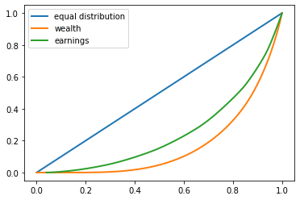

### Results

The above figure illustrates the Lorenz curves of earnings (green line) and wealth (orange line) which will result from our computation (final output). In steady state of our model, the (earnings-)poorest quintile of the workers receives only 3% of total earnings, while the top quintile earns 54% of total earnings. The Gini coefficient of earnings amounts to 0.50. Earnings are more concentrated than hourly wages as the more productive workers supply higher labor than the less productive workers in our model (as observed empirically).

Wealth is more concentrated than earnings. The (wealth-)poorest quintile holds no wealth at all (20% of the population are credit-constrained), while the top quintile of the wealth distribution holds 67% of total wealth. The Gini coefficient amounts to 0.66. Therefore, our model is able to replicate the fact that wealth is distributed more unequally than earnings. Our inequality of wealth falls a little short of empirical values because we neglect 1) bequests (Rockefeller's progeny), 2) entrepreneurship (Bill Gates), or 3) uncertain medical expenditures in old age in our model, among others.

### Computation of the Steady State

The algorithm for the computation of the steady state consists of the following steps:

1. Parameterize the model and choose asset grids for the individual state space.
2. Make initial guesses of the steady state values of the aggregate capital stock $\tilde K$, labor $\tilde L$, mean working hours $\bar l$, labor income taxes $\tau^l$, the social security contribution rate $\tau^p$ and government transfers $\widetilde{tr}$.
3. Compute the values $w$, $r$, and $\widetilde{pen}$, which solve the firm's Euler equation and the budget of the social security authority.
4. Compute the household's decision functions by backward induction using value function iteration.
5. Compute the optimal path for consumption, savings and labor supply for the new-born generation by forward induction given the initial asset level $\tilde a^1=0$ and distribution of idiosyncratic productivities $e$ and $\theta$.
6. Compute the aggregate savings $\tilde \Omega$, labor supply $\tilde L$, mean working hours $\bar l$, aggregate taxes and transfers $\widetilde{tr}$.
7. Update the aggregate variables and return to step 3 until convergence.
8. Update the asset grid of the individual state space if necessary and return to step 3 until convergence.

Let us look at the program and anaylse the individual steps in detail.

#### Step 0: Setting up the PYTHON computer program

Please download the PYTHON code 'AK70_stochastic_income.py' and run it. In line 263, you specify the interpolation method. We set kind_tol = 'linear' for linear interpolation. If you would like to try cubic interpolation instead, just set kind_tol = 'cubic'. Notice that the computational time almost doubles with cubic interpolation.

The computational time amounts to approximately 29 hours on my computer (the GAUSS code is about 60 times faster). The solution for the aggregate variables are $\tilde K=1.596$, $\tilde L=0.310$, $\bar l = 0.305$, $\widetilde{tr}=0.0266$, $\widetilde{pen}=0.116$ and $\tau^p=11.6$%.

The program consists of an outer loop over the aggregate variables $(\tilde K,\tilde L,\widetilde{tr},\widetilde{pen}, \tau^p)$ and an inner loop that computes the policy functions as a solution to the value function iteration problem. After 29 iterations of the outer loop, the program execution stops when the aggregate capital stock $\tilde K$ and efficienct labor $\tilde L$ in two consecutive iterations diverge by less than 0.0001. In the inner loop, we just need one iteration since we can solve the finite lifetime value function problem backwards starting in the last period of life, $T=70$ and initialize the value function at this age as described above in the economic model.

In the following, I will present functions as they appear in the main part of the program. In the download version, we specified the functions in the beginning of the program instead so that it allows for easy editing.

https://python-programming.quantecon.org/intro.html

In addition, we set the interpolation mode to 'linear'.

```python
# Set-up program: import libraries
import pandas as pd
import numpy as np
#import scipy.optimize
import quantecon as qe
from scipy.stats import norm
from scipy import interpolate
import time
import math
import matplotlib.pyplot as plt

# abbreviations
exp = np.e
log = math.log

kind_tol = 'linear'     # interpolation of policy functions:
                        # 'linear' or 'Cubic'
```